# Moose

[NO_MOOS_001]

Authors

Affiliations

Aud H. Halbritter

University of Bergen

Erik Framstad

Norwegian Institute for Nature Research

Katrine Eldegard

Norwegian University of Life Sciences

Published

May 15, 2026

> **Recommended citation**: Halbritter, A. H., Framstad, E., and Eldegard, K. 2026. Moose [Elg] (ID(s): NO_MOOS_001) v. 1.0.0. ecRxiv: https://github.com/NINAnor/ecRxiv/tree/main/indicators/NO_MOOS_001

**TipMetadata**

Table 1: Indicator metadata

| Variable | Value |
| --- | --- |
| Indicator ID | NO_MOOS_001 |
| Indicator Name | Moose [Elg] |
| verbatimName | Elg |
| Country | Norway |
| Continent | Europe |
| Ecosystem Condition Typology Class | B3 Functional state characteristics |
| Realm | Terrestrial (T) |
| Biome | T2 Temperate-boreal forests and woodlands biome |
| Ecosystem | T2.1 Boreal/montane forests |
| Year added | 2026 |
| Last update | 2026 |
| Version | 1.0.0 |
| Version comment | First version on ecRxiv; indicator described in the Norwegian Nature Index |
| Normalised | TRUE |
| Spatial aggregation pathway | Data (county level) - [Scale - Truncate - Transform] - Aggregate (national level) |
| Precision |  |

**TipLog**

- May 15, 2026 - Initial draft for ecRxiv

## 1. Summary

1. **Background and rationale**: The moose (*Alces alces*) is the largest ungulate found in forest ecosystems in Norway. Through browsing on tree saplings and shrubs, particularly pine, rowan and willow, moose exert a strong influence on tree regeneration, forest structure and plant biodiversity, and as a large prey animal form a central component of the prey base for apex predators (Niedziałkowska et al. 2022; Rodgers et al. 2025). In the period with reasonably good overview of cervid densities in Norway (about the last 200 years), populations have been strongly influenced by human activity. In many areas, moose densities have historically exceeded, and in some areas continue to exceed, the reference condition, resulting in impacts on forest regeneration and vegetation composition.
2. **Methods**: The moose indicator (elg) expresses population density as number of individuals per km² below the climatic tree line, reported at county level, as described on [Naturindeksen – elg](https://naturindeks.no/Indicators/elg). Underlying population information for moose in Norway is linked to the national monitoring programme for cervids, which has operated since 1991 and is owned by Landbruksdirektoratet and run by NINA (Landbruksdirektoratet and Norwegian Institute for Nature Research 2026). Much of the monitoring material is collected from animals harvested during hunting (for example jaw bones, slaughter weight, and for moose also reproductive organs from females) (Landbruksdirektoratet and Norwegian Institute for Nature Research 2026). The reference condition is an expert-assessed state in which moose occur throughout suitable forest habitat under current climate conditions, with natural, non-managed predator regimes, and in the absence of forest management . Estimated densities by county are normalised using a unimodal scaling function. Scaled county values are aggregated to five geographic regions and national level.
3. **Interpretation**: An indicator value of 1 means that moose abundance in the reporting unit is as large as expected under the reference condition. Values <1 indicate that the density is either lower or higher than the reference value.
4. **Results and development needs**: For the current reporting period (2020-2024) the national indicator value is 0.54, with a much higher value for region South (0.77) and an extremely low value for region West (0.00). The national indicator value has increased from 0.39 in 1990. Trends for values in different regions have varied between regions and periods. There are no specific development needs, except for a possible review of reference values and the scaling function.

## 1.2 Native language summary - Norwegian

1. **Bakgrunn og begrunnelse**: Elg (*Alces alces*) er det største hjortedyret i norske skogsøkosystemer. Gjennom beiting på busker og unge trær, særlig furu, rogn og vier, utøver elgen en sterk innflytelse på foryngelse av skog, skogsstruktur og plantebiodiversitet, og som et stort byttedyr utgjør den en sentral del av byttegrunnlaget for toppredatorer (Niedziałkowska et al. 2022; Rodgers et al. 2025). I perioden med rimelig oversikt over hjortevilttettheter i Norge (ca. 200 år) har bestandene vært sterkt påvirket av menneskelig aktivitet. I mange områder har elgtettheten historisk overskredet referansetilstanden, og gjør det fortsatt i enkelte områder, noe som har resultert i betydelige påvirkninger på skogens foryngelse og vegetasjonssammensetning.
2. **Metoder**: Indikatoren for elgbestand uttrykker tetthet som antall individer per km² under den klimatiske tregrensen, rapportert på fylkesnivå, som beskrevet på [Naturindeksen – elg](https://naturindeks.no/Indicators/elg). Underliggende bestandsinformasjon er knyttet til det nasjonale overvåkingsprogrammet for hjortevilt (Landbruksdirektoratet and Norwegian Institute for Nature Research 2026), med mye materiale fra jakt (Landbruksdirektoratet and Norwegian Institute for Nature Research 2026) og statistikk via [Hjorteviltregisteret](https://www.hjorteviltregisteret.no) (Landbruksdirektoratet 2026). Referansetilstanden er en ekspertvurdert tilstand der elg kan forekomme i egnete skogområder med dagens klima, med naturlige, ikke-regulerte rovdyrbestander, og uten skogforvaltning. Fylkesverdier normaliseres med en unimodal skaleringsfunksjon. Skalerte fylkesverdier aggregeres til fem geografiske regioner og nasjonalt nivå.
3. **Tolkning**: En indikatorverdi på 1 betyr at elgbestanden i rapporteringsenheten er like stor som forventet under referansetilstanden. Verdier <1 viser at tettheten enten er lavere eller høyere enn referanseverdien.
4. **Resultater og utviklingsbehov**: For nåværende rapporteringsperiode (2020-2024) er den nasjonale indikatoren 0,54, med mye verdi for region Sør (0,77) og ekstremt lav verdi for region Vest (0,00). For hele landet har indikatorverdien økt fra 0,39 i 1990. Treder for indikatorverdiene for ulike regioner variert mellom regioner og perioder. Det er ingen spesielle utviklingsbehov, med mulig unntak for en gjennomgang av referanseverdier og skaleringsfunksjonen.

## 2. About the underlying data

The moose data comes from the national cervid monitoring programme and Hjorteviltregisteret (Landbruksdirektoratet and Norwegian Institute for Nature Research 2026; Landbruksdirektoratet 2026).

### 2.1 Spatial and temporal resolution and extent

The underlying data are collected annually. Indicator values are available for the assessment years in Naturindeksen: 1990, 2000, 2010, 2014, 2019, and 2024.

To produce indicator estimates for these years, input is typically combined over a short window (typically two to three years).

Spatially, data and indicator values are handled at county level, then aggregated to five geographic regions and national level for reporting.

### 2.2 Sampling design

The national monitoring programme for cervids collects most material from harvested animals during hunting seasons (Landbruksdirektoratet and Norwegian Institute for Nature Research 2026). For moose, samples can include lower jaw and slaughter weight, and reproductive organs (egg stalks) from females (Landbruksdirektoratet and Norwegian Institute for Nature Research 2026). Further methodological details are given on [Naturindeksen – elg](https://naturindeks.no/Indicators/elg).

### 2.3 Original units

The moose abundance is expressed as number of individuals per km².

### 2.4 Instructions for citing, using and accessing data

The underlying data on hunting statistics are available upon request from Hjorteviltregisteret (Landbruksdirektoratet 2026). However, these data must be combined with data on demographic variables and other parameters to calculate the density of moose per county, as described [here](https://naturindeks.nina.no/docs/1c2b2f52-4d91-4563-b65d-b9813798dd06.pdf). The resulting data for the density of moose can be accessed directly and used in calculating scaled indicator values as described in sections 7 and 9 below.

Indicator values from the Norwegian Nature Index can be found in Nater, Zeiner-Henriksen, and Nybø (2025). Indicator values, variable values and reference values can be downloaded from the Nature Index database using the API, as I have done below. The data is licenced under CC-BY 4.0.

## 3. Indicator properties

### 3.1 Ecosystem Condition Typology Class (ECT)

Large herbivores may potentially have a strong impact on the composition of the vegetation and the recruitment of tree species. Hence, this indicator is considered to fall under B3 Functional state characteristics.

### 3.2 Ecosystem condition characteristic

### 3.3 Collinearities with other indicators

The indicator may covary with other cervid abundance indicators (red deer, roe deer) and with other species indicators that share similar habitats or data sources.

### 3.4 Impact factors

One of the major natural impact factors is variation in weather conditions, especially temperature during reproduction and snow conditions in winter, affecting food quality and availability, recruitment and survival. Predation from large carnivores and disease and parasites are other key factors affecting survival. Major anthropogenic impact factors are land use change, traffic accidents, hunting, strong limitation of large carnivore populations, and climate change.

## 4. Reference condition and levels

### 4.1 Reference condition

The species-specific reference condition for moose represents the natural population state occurring in the absence of significant human influence, where population size, structure and dynamics are regulated primarily by natural processes – including predation by natural carnivore communities, particularly wolves, food availability, and habitat carrying capacity under natural vegetation conditions. The population fulfills its natural functional role as the dominant large herbivore in forest ecosystems, exerting strong influence on tree regeneration, forest structure and plant biodiversity through browsing on tree saplings and shrubs – particularly pine, rowan and willow – at naturally occurring intensities, and forming a central prey base for apex predators. Population size naturally varies within dynamic ranges in response to climatic variation, natural disturbance regimes, and ecological interactions with other herbivores such as red deer and roe deer.

### 4.2 Reference levels

#### 4.2.1 Spatial resolution and validity

Reference levels and indicator values apply at county level. Aggregated results for five geographic regions and for Norway are area-weighted average indicator values for included counties. Normalisation should be done at county level before regional or national aggregation.

## 5. Uncertainties

### 5.1 General uncertainties

Reference levels are held fixed in this workflow (their own uncertainties are not propagated). Regional and national values are area-weighted average indicator values for included counties, so they inherit both model uncertainty at county level and any mismatch between county boundaries and ecological variation within regions.

### 5.2 Reported uncertainties

The intervals in Table 2, Table 3 and Figure 2 are inferential: they describe uncertainty around the estimated area-weighted mean indicator for each reporting unit (a geographic region or Norway as a whole), given the statistical models used for county-level density in Naturindeks.

For each county and assessment year, Naturindeks provides a predictive distribution for density (expressed as variable values before scaling). We draw many random values from that distribution per county, scale each draw to the 0–1 indicator scale using the county reference optimum and unimodal scaling, then build a large set of possible county indicator values. To obtain uncertainty for a region, we repeat the following 1000 times: draw one random county indicator value per county in that region, take the forest-area-weighted average across those counties, and record that regional mean. The median of those regional means is reported as the point estimate; the 2.5% and 97.5% quantiles form an approximate 95% interval, and the 25% and 75% quantiles form an approximate interquartile range. For Norway, we apply a second Monte Carlo step at regional level: draw one value from each region’s uncertainty distribution, take the forest-area-weighted mean across the five regions, and repeat 1000 times to obtain a national distribution, then summarise in the same way. This approach reflects uncertainty in the county models and in the scaled values, while treating the regional or national figure as a single summary parameter rather than as a random draw from one county.

## 6. References

Landbruksdirektoratet. 2026. “Hjorteviltregisteret.” https://www.hjorteviltregisteret.no.

Landbruksdirektoratet, and Norwegian Institute for Nature Research. 2026. “Nasjonalt Overvåkingsprogram for Hjortevilt.” https://hjortevilt.no/forskning-og-viltovervaking/nasjonalt-bestandsovervakningsprogram-for-hjortevilt-bop.

Nater, Chloé Rebecca, Tuva Zeiner-Henriksen, and Signe Nybø. 2025. “NI2025: Indicator Data.” https://doi.org/10.21345/y790-v762.

Niedziałkowska, M., W. Neumann, T. Borowik, M. Kołodziej-Sobocińska, J. Malmsten, J. M. Arnemo, and G. Ericsson. 2022. “Moose *Alces Alces* (Linnaeus, 1758).” In *Terrestrial Cetartiodactyla*, edited by L. Corlatti and F. E. Zachos. Handbook of the Mammals of Europe. Cham: Springer. https://doi.org/10.1007/978-3-030-24475-0_23.

Norwegian Institute for Nature Research, and partners. 2025. “Norwegian Nature Index (Naturindeks).” https://www.naturindeks.no.

Rodgers, A. R., L. Baskin, I. Herfindal, W. Jensen, G. Kuzyk, P. Pekins, and C. M. Rolandsen. 2025. “Moose *Alces Alces* (Linnaeus, 1758).” In *Deer of the World*, edited by M. Melletti and S. Focardi. Fascinating Life Sciences. Cham: Springer. https://doi.org/10.1007/978-3-031-17756-9_55.

## 7. Import and prepare datasets

Run the download chunk once to refresh the local export. This project’s renv environment installs `NIcalc` from GitHub `ChloeRN/NIcalc`, branch `include_ReadOnly_access` (see `renv.lock` and `install_deps.R`); that build defaults to the Naturindeks read-only API user, so you do not need `username` / `password` arguments here. When [NINAnor/NIcalc PR #59](https://github.com/NINAnor/NIcalc/pull/59) is merged into `NINAnor/NIcalc`, you can switch the renv install back to the main repo and update the lockfile. We save the RDS export under `data/` so that we do not need to download the data every time we run the analysis.

**Download moose data from Naturindeks API**

```r
moosImport <- NIcalc::importDatasetApi(
  eco = NULL,
  indic = c("Elg"),
  year = c("1990", "2000", "2010", "2014", "2019", "2024")
)

saveRDS(moosImport, here::here("data/moosImport.rds"))
```

## 9. Analyses

This section uses the following workflow: we take variable values and reference levels from the Naturindeks import, normalise at county level, then propagate uncertainty and aggregate spatially with area weights using `ecTools::ec_upscale()`. At regional and national levels, uncertainties are inferential: each replicate is an area-weighted mean based on one draw per county (then, for Norway, one draw per region). We use unimodal scaling and forest area (`Skog`) as weights.

County-level abundance in the Naturindeksdatabase is stored as a predictive distribution (parameters or custom distributions), not only as a point estimate. Reference optimum density per county comes from the reference slice of the same download (`expectedValue` for the reference year). We ignore uncertainty in reference levels.

### Assemble import and indicator object

`assembleNiObject()` reshapes `moosImport` so that indicator observations are in one list element per assessment year, and so that municipality-level `BSunits` (with forest area and NI region code `part`) are aligned with the thematic index structure used in Naturindeks.

**Assemble moose NI object (thematic, predefined regions)**

```r
moosAssemble <- NIcalc::assembleNiObject(
  inputData = moosImport,
  predefNIunits = c(allArea = T, parts = T, counties = F),
  indexType = "thematic"
)
```

```
Check input data .....
```

```
Elicitate incomplete reference values and indicator observations .....
```

```
Assemble dataset .....
```

### Reference levels (X<sub>100</sub>)

Before scaling, we need the county-specific optimum on the variable scale (moose density, ind. km⁻² below the tree line). These are read from `referenceValues` in the RDS export (rows with `yearId == 0` or reference year name), one `x100` per IC unit (county).

**County reference optimum (X100) from downloaded Naturindeks data**

```r
x100 <- moosImport$referenceValues$referenceValues |>
  dplyr::filter(.data$yearId == 0L | grepl("Referanse", .data$yearName, fixed = FALSE)) |>
  dplyr::distinct(ICunitId, ICunitName, x100 = expectedValue)
x100 |>
  gt::gt()
```

County reference optimum (X100) by county (IC unit).

| ICunitId | ICunitName | x100 |
| --- | --- | --- |
| 3613 | Østfold | 0.5 |
| 3614 | Akershus | 0.5 |
| 3615 | Hedmark | 0.4 |
| 3616 | Oppland | 0.4 |
| 3617 | Buskerud | 0.4 |
| 3618 | Vestfold | 0.5 |
| 3619 | Telemark | 0.3 |
| 3620 | Aust-Agder | 0.3 |
| 3621 | Vest-Agder | 0.3 |
| 3622 | Rogaland | 0.2 |
| 3623 | Hordaland | 0.2 |
| 3624 | Sogn og Fjordane | 0.2 |
| 3625 | Møre og Romsdal | 0.2 |
| 3626 | Sør-Trøndelag | 0.4 |
| 3627 | Nord-Trøndelag | 0.4 |
| 3628 | Nordland | 0.3 |
| 3629 | Troms | 0.3 |
| 3630 | Finnmark | 0.1 |

### Resample non-scaled county-level variables

For each assessment year, Naturindeks stores county values as a parameterised distribution (or a custom distribution). We draw `nsim = 1000` random values per county with `NIcalc::sampleObsMat()`. Rows with a standard distribution family use observation type `tradObs`; rows with only a custom distribution use `customObs`.

Assessment years are the following: 1990, 2000, 2010, 2014, 2019, 2024. The result `county_draws` is a long table of simulated variable values (`value`) by `ICunitId` and `year` (not yet on the 0–1 indicator scale).

**Observation types for sampleObsMat**

```r
myYears <- as.character(c(1990, 2000, 2010, 2014, 2019, 2024))
obstype <- vector("list", length(myYears))
for (i in seq_along(myYears)) {
  obs <- moosAssemble$indicatorValues[[i]]$distributionFamilyName
  obs[!is.na(obs)] <- "tradObs"
  obs[is.na(obs)] <- "customObs"
  obstype[[i]] <- obs
}
```

**Resample county-scale variables (non-scaled)**

```r
county_draws <- tibble(ICunitId = NULL, value = NULL, year = NULL)

for (i in seq_along(myYears)) {
  myMat <- NIcalc::sampleObsMat(
    ICunitId = moosAssemble$indicatorValues[[i]]$ICunitId,
    value = moosAssemble$indicatorValues[[i]]$expectedValue,
    distrib = moosAssemble$indicatorValues[[i]]$distributionFamilyName,
    mu = moosAssemble$indicatorValues[[i]]$distParameter1,
    sig = moosAssemble$indicatorValues[[i]]$distParameter2,
    customDistribution = moosAssemble$indicatorValues[[i]]$customDistribution,
    obsType = obstype[[i]],
    nsim = 1000
  )
  ICunitIds <- row.names(myMat)
  colnames(myMat) <- paste0("s", seq_len(ncol(myMat)))
  myMat <- myMat |>
    as_tibble() |>
    add_column(ICunitId = ICunitIds, .before = 1) |>
    pivot_longer(cols = -any_of("ICunitId"), names_to = "sim_col", values_to = "value") |>
    mutate(
      sim_id = readr::parse_number(.data$sim_col),
      year = myYears[i]
    ) |>
    select(ICunitId, sim_id, value, year)

  county_draws <- county_draws |>
    bind_rows(myMat)
}
head(county_draws) |>
  gt::gt()
```

Preview of resampled county-scale variable values (first rows).

| ICunitId | sim_id | value | year |
| --- | --- | --- | --- |
| 3613 | 1 | 0.6081418 | 1990 |
| 3613 | 2 | 0.5781980 | 1990 |
| 3613 | 3 | 0.5537709 | 1990 |
| 3613 | 4 | 0.5665698 | 1990 |
| 3613 | 5 | 0.8887039 | 1990 |
| 3613 | 6 | 0.4209607 | 1990 |

### Scaling to indicator values (unimodal)

Normalisation is done at county scale before any regional or national aggregation. Each draw is joined to its county `x100`, then mapped to `[0, 1]` with `ecTools::ec_normalise()` in two-sided mode: `x0 = 0` and `x100` = optimum from the download define the best condition; `x0h = 3 * x100` is a simple upper anchor for “too high” density (adjust if you adopt explicit upper limits from NI documentation). The `sigmoid` option applies a non-linear transform after the piecewise linear mapping.

**Join X100 and unimodal scaling to indicator scale**

```r
county_draws <- county_draws |>
  left_join(x100 |> mutate(ICunitId = as.character(ICunitId)), by = join_by(ICunitId))

ind <- ec_normalise(
  variable = county_draws$value,
  x0 = 0,
  x100 = county_draws$x100,
  x0h = 3 * county_draws$x100,
  fun = "sigmoid"
)

county_draws <- county_draws |> add_column(indicator = ind)
```

The scatter plot below (Figure 1) shows the mapping from variable to indicator for each county (one facet per `ICunitName`). The figure is saved when the document is rendered.

**Save normalisation diagnostic figure (English)**

```r
moose_plot <- ec_norm_plot(county_draws$value, county_draws$indicator) +
  ggplot2::facet_wrap(~ county_draws$ICunitName, scales = "free_x") +
  ggplot2::theme(axis.text = ggplot2::element_text(size = 9))
moose_plot$layers[[1]]$aes_params$size <- 3
suppressMessages(
  ggsave(filename = here::here("img/moos_norm_plot_eng.png"), plot = moose_plot, scale = 1.5)
)
```

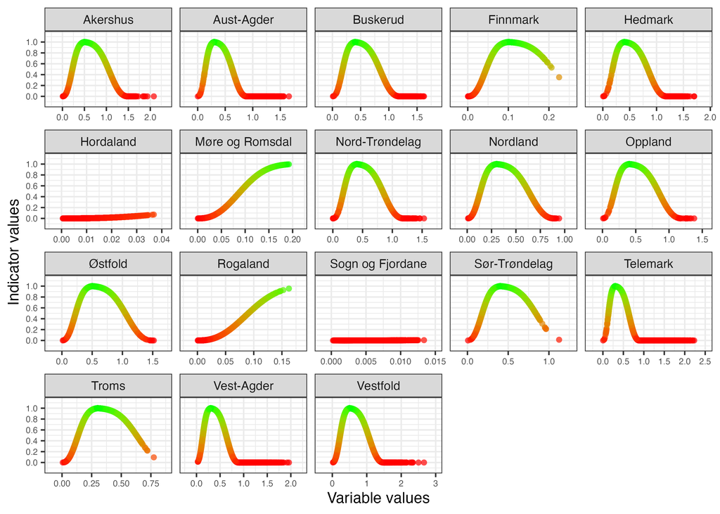

Figure 1: Unimodal normalisation of moose density to indicator values (one panel per county).

```r
knitr::include_graphics(here::here("img/moos_norm_plot_eng.png"))
```

### Aggregation weights (forest area by county)

Spatial aggregation uses area below the tree line recorded in Naturindeks (`Skog` on each municipality in `BSunits`). Municipalities are linked to counties via `ICunits`, then forest area is summed to county (`ICunitId`) and the NI region `part` (N, C, W, S, E) is kept for the next step. Each row in `county_draws` then carries `forest_area` and `part` for weighting.

**Forest area by county and NI region for aggregation weights**

```r
county_weights <- as_tibble(moosAssemble$BSunits) |>
  rename(BSunitId = id)

IC_BC_link <- moosImport$ICunits |>
  select(ICunitId = id, BSunitId)

county_weights <- county_weights |>
  left_join(IC_BC_link, by = join_by(BSunitId))

county_weights <- county_weights |>
  group_by(ICunitId) |>
  summarise(forest_area = sum(Skog), part = unique(part)) |>
  mutate(ICunitId = as.character(ICunitId))

county_draws <- county_draws |>
  left_join(county_weights, by = join_by(ICunitId))
```

### Spatial aggregation

Aggregate from counties to geographic regions with `ecTools::ec_upscale()`, using Monte Carlo propagation of inferential uncertainty (one draw per county per replicate, forest-area-weighted mean).

**County to region MC propagation (ec_upscale)**

```r
mc_propagated <- ecTools::ec_upscale(
  data = county_draws,
  variable = indicator,
  weight = forest_area,
  start_units = ICunitId,
  end_units = part,
  year = year,
  end_units_name = "part",
  n = 1000
)
saveRDS(mc_propagated, here::here("data/moos_mc_propagated_regional.rds"))
```

For the national indicator, propagate again from regions to Norway. Summed forest area per geographic region is used as weight at this step.

**Total forest area per NI region**

```r
region_weights <- county_weights |>
  group_by(part) |>
  summarise(forest_area = sum(.data$forest_area), .groups = "drop")
region_weights
```

```
# A tibble: 5 × 2
  part  forest_area
  <chr>       <dbl>
1 C          20568.
2 E          39436.
3 N          30469.
4 S          18229.
5 W          11479.
```

**Region to Norway MC propagation (ec_upscale)**

```r
mc_propagated_for_national <- mc_propagated |>
  left_join(region_weights, by = join_by(part)) |>
  add_column(end_units = "Norway")

mc_propagated_national <- ecTools::ec_upscale(
  data = mc_propagated_for_national,
  variable = sampled_mean,
  weight = forest_area,
  start_units = part,
  end_units = end_units,
  year = year,
  end_units_name = "part",
  n = 1000
)
saveRDS(mc_propagated_national, here::here("data/moos_mc_propagated_national.rds"))
```

Regional and national MC draws are combined for summarisation and export.

**Bind regional and national MC outputs**

```r
mc_propagated_combined <- mc_propagated |>
  select(year, part, sampled_mean) |>
  bind_rows(mc_propagated_national)
```

## 10. Results

From the 1000 Monte Carlo replicates per region and year in `mc_propagated_combined`, we report the median as the point estimate and use the 2.5% and 97.5% quantiles as an approximate 95% interval for the area-weighted mean indicator (inferential uncertainty, not descriptive between-county spread). The tables (Table 2 and Table 3) and time series (Figure 2) summarise regional and national (`Norway`) values.

```r
summary_out <- mc_propagated_combined |>
  mutate(part = dplyr::recode(part, !!!moos_part_labels)) |>
  group_by(part, year) |>
  summarise(
    median = round(median(sampled_mean), 2),
    p_025 = round(quantile(sampled_mean, probs = 0.025), 2),
    p_25 = round(quantile(sampled_mean, probs = 0.25), 2),
    p_75 = round(quantile(sampled_mean, probs = 0.75), 2),
    p_975 = round(quantile(sampled_mean, probs = 0.975), 2),
    .groups = "drop"
  ) |>
  mutate(part = factor(part, levels = moos_region_levels)) |>
  add_column(
    ECT = "B3",
    Indicator = "Moose abundance",
    Ecosystem = "Boreal/montane forests",
    ID = "NO_MOOS_001"
  )
```

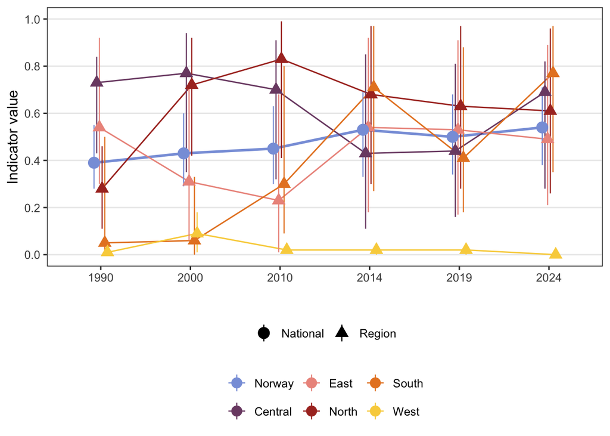

Figure 2: Indicator values for moose abundance by region and nationally, with uncertainty bands from the resampled distribution.

```r
moos_plot_years <- as.character(c(1990, 2000, 2010, 2014, 2019, 2024))
moos_region_cols <- setNames(
  MetBrewer::met.brewer("Archambault", n = length(moos_region_levels)),
  moos_region_levels
)

plot_data <- summary_out |>
  mutate(
    year = factor(year, levels = moos_plot_years),
    series_type = if_else(part == "Norway", "National", "Region")
  )

ggplot(plot_data, aes(x = year, y = median, colour = part, group = part)) +
  geom_line(
    aes(linewidth = series_type),
    position = position_dodge(width = 0.18)
  ) +
  geom_pointrange(
    aes(ymin = p_025, ymax = p_975, shape = series_type),
    size = 0.8,
    linewidth = 0.45,
    position = position_dodge(width = 0.18)
  ) +
  scale_colour_manual(values = moos_region_cols, name = NULL) +
  scale_shape_manual(
    values = c(National = 19, Region = 17),
    name = NULL
  ) +
  scale_linewidth_manual(
    values = c(National = 1, Region = 0.55),
    guide = "none"
  ) +
  scale_y_continuous(limits = c(0, 1), breaks = seq(0, 1, 0.2)) +
  theme_bw(base_size = 12) +
  theme(
    legend.position = "bottom",
    legend.box = "vertical",
    panel.grid.minor = element_blank(),
    panel.grid.major.x = element_blank()
  ) +
  guides(
    colour = guide_legend(nrow = 2, override.aes = list(size = 0.7, linewidth = 0.45)),
    shape = guide_legend(override.aes = list(size = 0.8, linewidth = 0.45))
  ) +
  labs(y = "Indicator value", x = "")
```

```r
summary_out |>
  filter(part != "Norway") |>
  arrange(part, year) |>
  unite(col = "CI_95", c(p_025, p_975), sep = " - ") |>
  unite(col = "IQR", c(p_25, p_75), sep = " - ") |>
  select(
    ECT,
    Indicator,
    ID,
    "Accounting area" = part,
    Ecosystem,
    "Closing year" = year,
    "Indicator value" = median,
    "95% CI" = CI_95,
    "50% CI" = IQR
  ) |>
  kable()
```

Table 2: Indicator values and uncertainty estimates for moose abundance by region.

| ECT | Indicator | ID | Accounting area | Ecosystem | Closing year | Indicator value | 95% CI | 50% CI |
| --- | --- | --- | --- | --- | --- | --- | --- | --- |
| B3 | Moose abundance | NO_MOOS_001 | Central | Boreal/montane forests | 1990 | 0.73 | 0.43 - 0.84 | 0.66 - 0.78 |
| B3 | Moose abundance | NO_MOOS_001 | Central | Boreal/montane forests | 2000 | 0.77 | 0.35 - 0.94 | 0.59 - 0.85 |
| B3 | Moose abundance | NO_MOOS_001 | Central | Boreal/montane forests | 2010 | 0.70 | 0.32 - 0.91 | 0.51 - 0.8 |
| B3 | Moose abundance | NO_MOOS_001 | Central | Boreal/montane forests | 2014 | 0.43 | 0.11 - 0.85 | 0.35 - 0.53 |
| B3 | Moose abundance | NO_MOOS_001 | Central | Boreal/montane forests | 2019 | 0.44 | 0.16 - 0.81 | 0.35 - 0.67 |
| B3 | Moose abundance | NO_MOOS_001 | Central | Boreal/montane forests | 2024 | 0.69 | 0.28 - 0.82 | 0.52 - 0.76 |
| B3 | Moose abundance | NO_MOOS_001 | East | Boreal/montane forests | 1990 | 0.54 | 0.3 - 0.92 | 0.46 - 0.67 |
| B3 | Moose abundance | NO_MOOS_001 | East | Boreal/montane forests | 2000 | 0.31 | 0.06 - 0.73 | 0.21 - 0.43 |
| B3 | Moose abundance | NO_MOOS_001 | East | Boreal/montane forests | 2010 | 0.23 | 0.01 - 0.68 | 0.11 - 0.35 |
| B3 | Moose abundance | NO_MOOS_001 | East | Boreal/montane forests | 2014 | 0.54 | 0.18 - 0.92 | 0.39 - 0.69 |
| B3 | Moose abundance | NO_MOOS_001 | East | Boreal/montane forests | 2019 | 0.53 | 0.17 - 0.91 | 0.4 - 0.7 |
| B3 | Moose abundance | NO_MOOS_001 | East | Boreal/montane forests | 2024 | 0.49 | 0.21 - 0.89 | 0.37 - 0.58 |
| B3 | Moose abundance | NO_MOOS_001 | North | Boreal/montane forests | 1990 | 0.28 | 0.11 - 0.46 | 0.21 - 0.35 |
| B3 | Moose abundance | NO_MOOS_001 | North | Boreal/montane forests | 2000 | 0.72 | 0.42 - 0.92 | 0.62 - 0.81 |
| B3 | Moose abundance | NO_MOOS_001 | North | Boreal/montane forests | 2010 | 0.83 | 0.41 - 0.99 | 0.67 - 0.93 |
| B3 | Moose abundance | NO_MOOS_001 | North | Boreal/montane forests | 2014 | 0.68 | 0.3 - 0.97 | 0.55 - 0.83 |
| B3 | Moose abundance | NO_MOOS_001 | North | Boreal/montane forests | 2019 | 0.63 | 0.28 - 0.97 | 0.56 - 0.8 |
| B3 | Moose abundance | NO_MOOS_001 | North | Boreal/montane forests | 2024 | 0.61 | 0.26 - 0.96 | 0.5 - 0.77 |
| B3 | Moose abundance | NO_MOOS_001 | South | Boreal/montane forests | 1990 | 0.05 | 0 - 0.5 | 0 - 0.25 |
| B3 | Moose abundance | NO_MOOS_001 | South | Boreal/montane forests | 2000 | 0.06 | 0 - 0.33 | 0 - 0.15 |
| B3 | Moose abundance | NO_MOOS_001 | South | Boreal/montane forests | 2010 | 0.30 | 0.09 - 0.8 | 0.23 - 0.47 |
| B3 | Moose abundance | NO_MOOS_001 | South | Boreal/montane forests | 2014 | 0.71 | 0.27 - 0.97 | 0.52 - 0.85 |
| B3 | Moose abundance | NO_MOOS_001 | South | Boreal/montane forests | 2019 | 0.41 | 0.18 - 0.88 | 0.27 - 0.53 |
| B3 | Moose abundance | NO_MOOS_001 | South | Boreal/montane forests | 2024 | 0.77 | 0.35 - 0.97 | 0.61 - 0.88 |
| B3 | Moose abundance | NO_MOOS_001 | West | Boreal/montane forests | 1990 | 0.01 | 0 - 0.02 | 0 - 0.01 |
| B3 | Moose abundance | NO_MOOS_001 | West | Boreal/montane forests | 2000 | 0.09 | 0.01 - 0.18 | 0.06 - 0.13 |
| B3 | Moose abundance | NO_MOOS_001 | West | Boreal/montane forests | 2010 | 0.02 | 0.01 - 0.05 | 0.01 - 0.03 |
| B3 | Moose abundance | NO_MOOS_001 | West | Boreal/montane forests | 2014 | 0.02 | 0 - 0.04 | 0.01 - 0.03 |
| B3 | Moose abundance | NO_MOOS_001 | West | Boreal/montane forests | 2019 | 0.02 | 0 - 0.04 | 0.01 - 0.02 |
| B3 | Moose abundance | NO_MOOS_001 | West | Boreal/montane forests | 2024 | 0.00 | 0 - 0 | 0 - 0 |

```r
summary_out |>
  filter(part == "Norway") |>
  arrange(part, year) |>
  unite(col = "CI_95", c(p_025, p_975), sep = " - ") |>
  unite(col = "IQR", c(p_25, p_75), sep = " - ") |>
  select(
    ECT,
    Indicator,
    ID,
    "Accounting area" = part,
    Ecosystem,
    "Closing year" = year,
    "Indicator value" = median,
    "95% CI" = CI_95,
    "50% CI" = IQR
  ) |>
  kable()
```

Table 3: Indicator values and uncertainty estimates for moose abundance at national level.

| ECT | Indicator | ID | Accounting area | Ecosystem | Closing year | Indicator value | 95% CI | 50% CI |
| --- | --- | --- | --- | --- | --- | --- | --- | --- |
| B3 | Moose abundance | NO_MOOS_001 | Norway | Boreal/montane forests | 1990 | 0.39 | 0.28 - 0.55 | 0.36 - 0.45 |
| B3 | Moose abundance | NO_MOOS_001 | Norway | Boreal/montane forests | 2000 | 0.43 | 0.29 - 0.6 | 0.38 - 0.48 |
| B3 | Moose abundance | NO_MOOS_001 | Norway | Boreal/montane forests | 2010 | 0.45 | 0.3 - 0.63 | 0.39 - 0.51 |
| B3 | Moose abundance | NO_MOOS_001 | Norway | Boreal/montane forests | 2014 | 0.53 | 0.33 - 0.69 | 0.46 - 0.58 |
| B3 | Moose abundance | NO_MOOS_001 | Norway | Boreal/montane forests | 2019 | 0.50 | 0.34 - 0.68 | 0.44 - 0.56 |
| B3 | Moose abundance | NO_MOOS_001 | Norway | Boreal/montane forests | 2024 | 0.54 | 0.38 - 0.71 | 0.49 - 0.6 |

## 11. Export file

Regional and national Monte Carlo draws are exported in one table (`mc_propagated_combined`: `year`, `part`, `sampled_mean`; `part` includes NI regions and `Norway`).

**Export regional and national MC-propagated indicator draws**

```r
write.csv(
  mc_propagated_combined,
  here::here("data/results_NO_MOOS_001_v1.0.0.csv"),
  row.names = FALSE
)
```

**CRediT statement**

- Conceptualization: [All]
- Methodology: [AHH]
- Formal analysis: [AHH]
- Writing – original draft: [AHH]
- Writing – review & editing: [All]

We would, also, like to acknowledge the work of those that created the indicator on *Naturindeks* (Norwegian Institute for Nature Research and partners 2025).

**TipSession Info**

This information is mainly aimed at developers that need to recreate the R environment that produced the html. Important note: this information is about the R session that was running when the html was rendered, and if some of the code chunks were not evaluated when the html was rendered, they may have been executed in a different environment.